# PISA Data Exploration

### What is PISA?

PISA is the OECD's Programme for International Student Assessment. Every three years it tests 15-year-old students from all over the world in reading, mathematics and science. The tests are designed to gauge how well the students master key subjects in order to be prepared for real-life situations in the adult world. Why choose 15-year-olds? Because in most countries, at the age of 15, students can decide whether or not they want to continue their education. They therefore need to be equipped for adult life. PISA publishes the results of the test a year after the students are tested to help governments shape their education policy. PISA cycles are referred to by the year in which the students were tested. Therefore PISA 2000 means the students were tested in the year 2000, PISA 2003, in the year 2003 and so forth. (www.oecd.org/pisa/)

### Dataset Overview

PISA 2012 data includes various features of investigated students, such as their possessions of certain furniture or their mindset towards learning. I analyzed this data with three different exploration, which are **univariate, bivariate and multivariate exploration.** In univariate exploration, I took closer look at **distribution** of students choice shown by **countplot.** I visualized the distribution of Student-Teacher Relationship and Sense of Belonging. In bivariate exploration, I took closer look at elements that might influence students' **score** and visualize the relationship between two variables using **heatmap.** Particulary, I researched if birth month or number of possessions influence score. Finally, in multivariate exploration, I figured out the relationship between two variables according to **gender** using **scatter plot.** For example, I visualized relationship between Perceived Control and Perserverance according to gender.

## Univariate Exploration

In univariate exploration, I will look at the distribution of single variable and use histogram to visualize the results.

- KEYWORD : Distribution, Countplot

### Q1. How is the student-teacher relation is distributed?

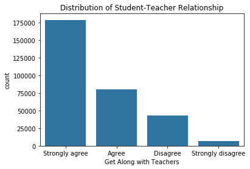

```python
# see distribution of each column by countplot
sb.countplot(x="Get Along with Teachers", data=relation, color = sb.color_palette()[0]);
plt.xticks(np.arange(4),('Strongly agree', 'Agree', 'Disagree', 'Strongly disagree'));
plt.title("Distribution of Student-Teacher Relationship");
```

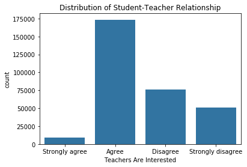

```python
sb.countplot(x="Teachers Are Interested", data=relation, color = sb.color_palette()[0]);
plt.xticks(np.arange(4),('Strongly agree', 'Agree', 'Disagree', 'Strongly disagree'));
plt.title("Distribution of Student-Teacher Relationship");
```

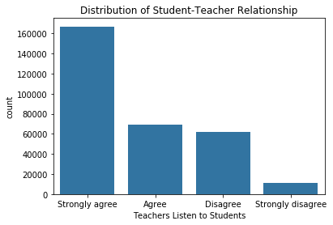

```python
sb.countplot(x="Teachers Listen to Students", data=relation, color = sb.color_palette()[0]);
plt.xticks(np.arange(4),('Strongly agree', 'Agree', 'Disagree', 'Strongly disagree'));
plt.title("Distribution of Student-Teacher Relationship");
```

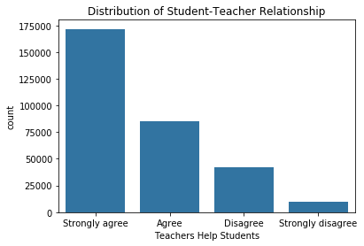

```python
sb.countplot(x="Teachers Help Students", data=relation, color = sb.color_palette()[0]);
plt.xticks(np.arange(4),('Strongly agree', 'Agree', 'Disagree', 'Strongly disagree'));
plt.title("Distribution of Student-Teacher Relationship");
```

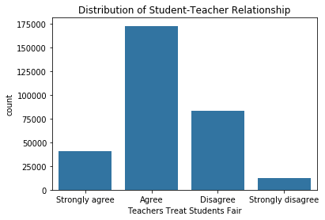

```python
sb.countplot(x="Teachers Treat Students Fair", data=relation, color = sb.color_palette()[0]);
plt.xticks(np.arange(4),('Strongly agree', 'Agree', 'Disagree', 'Strongly disagree'));
plt.title("Distribution of Student-Teacher Relationship");
```

#### A1.

Most Student-Teacher Relationship are in descending order, starting from strongly agree to strongly disagree, except two columns. The two columns are 'Teachers Are Interested' and 'Teachers Treat Students Fair'. The former's count on 'Strongly agree' was the least, and the latter's count on 'Strongly agree' was second to the least. Except 'Strongly agree', they are in descending order as well, starting from agree to strongly disagree

### Q2. How is the sense of belonging is distributed?

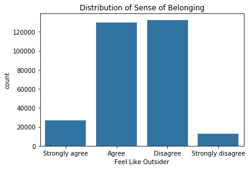

```python
# see distribution of each column by countplot
sb.countplot(x="Feel Like Outsider", data=belonging, color = sb.color_palette()[0]);
plt.xticks(np.arange(4),('Strongly agree', 'Agree', 'Disagree', 'Strongly disagree'));
plt.title("Distribution of Sense of Belonging");
```

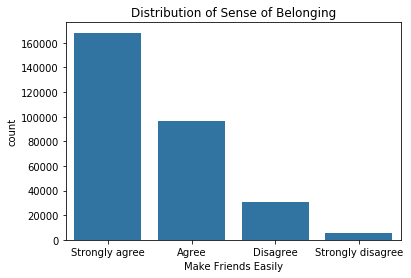

```python
sb.countplot(x="Make Friends Easily", data=belonging, color = sb.color_palette()[0]);
plt.xticks(np.arange(4),('Strongly agree', 'Agree', 'Disagree', 'Strongly disagree'));
plt.title("Distribution of Sense of Belonging");
```

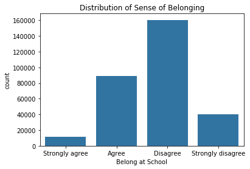

```python
sb.countplot(x="Belong at School", data=belonging, color = sb.color_palette()[0]);
plt.xticks(np.arange(4),('Strongly agree', 'Agree', 'Disagree', 'Strongly disagree'));
plt.title("Distribution of Sense of Belonging");
```

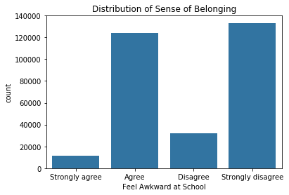

```python
sb.countplot(x="Feel Awkward at School", data=belonging, color = sb.color_palette()[0]);
plt.xticks(np.arange(4),('Strongly agree', 'Agree', 'Disagree', 'Strongly disagree'));
plt.title("Distribution of Sense of Belonging");
```

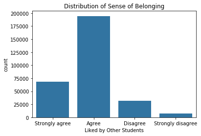

```python
sb.countplot(x="Liked by Other Students", data=belonging, color = sb.color_palette()[0]);
plt.xticks(np.arange(4),('Strongly agree', 'Agree', 'Disagree', 'Strongly disagree'));
plt.title("Distribution of Sense of Belonging");
```

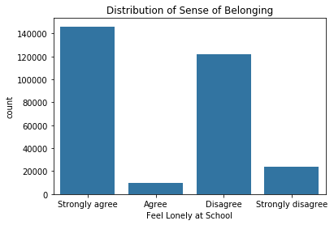

```python
sb.countplot(x="Feel Lonely at School", data=belonging, color = sb.color_palette()[0]);
plt.xticks(np.arange(4),('Strongly agree', 'Agree', 'Disagree', 'Strongly disagree'));
plt.title("Distribution of Sense of Belonging");
```

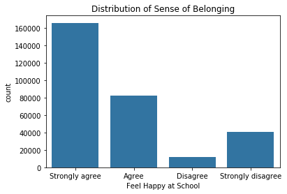

```python
sb.countplot(x="Feel Happy at School", data=belonging, color = sb.color_palette()[0]);
plt.xticks(np.arange(4),('Strongly agree', 'Agree', 'Disagree', 'Strongly disagree'));
plt.title("Distribution of Sense of Belonging");
```

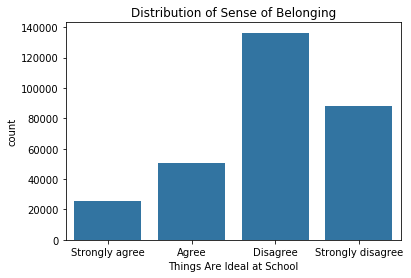

```python
sb.countplot(x="Things Are Ideal at School", data=belonging, color = sb.color_palette()[0]);
plt.xticks(np.arange(4),('Strongly agree', 'Agree', 'Disagree', 'Strongly disagree'));
plt.title("Distribution of Sense of Belonging");
```

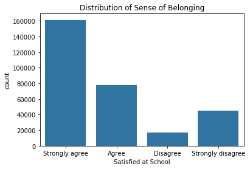

```python
sb.countplot(x="Satisfied at School", data=belonging, color = sb.color_palette()[0]);
plt.xticks(np.arange(4),('Strongly agree', 'Agree', 'Disagree', 'Strongly disagree'));
plt.title("Distribution of Sense of Belonging");
```

#### A2.

Most students choose 'Strongly agree' in 'Satisfied at School', 'Feel Happy at School', 'Feel Lonely at School', and 'Make Friends Easily'. Only in the column 'Liked by Other Students' choose students 'Agree' the most. In 'Feel Like Outsider', 'Belong at School', 'Things Are Ideal at School', most students picked 'Disagree'. And finally, most students 'strongly disagreed' in 'Feel Awkward at School'.

## Bivariate Exploration

In bivariate exploration, I will look at the realtionship between two variables and use heatmap to visualize the results.

- KEYWORD : Score, Heat Map

### Q1. How is the birth-month and score is related? Does being borned in earlier month have advantage in terms of score?

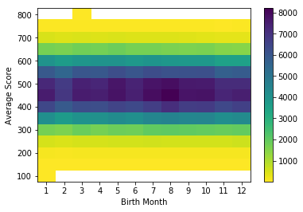

```python
# check the relationship between score and birth month by heatmap
plt.hist2d(data=score_birth, x='birth', y='score', cmin=10, cmap='viridis_r', bins=[bins_x, bins_y]);
plt.xticks((1,2,3,4,5,6,7,8,9,10,11,12))
plt.colorbar();
plt.xlabel('Birth Month');
plt.ylabel('Average Score');
```

#### A1.

There seems no clear relationship between birth month and score.

### Q2. How is the possessions and score is related? Is there any certain possession that acts as a great predictor of high score?

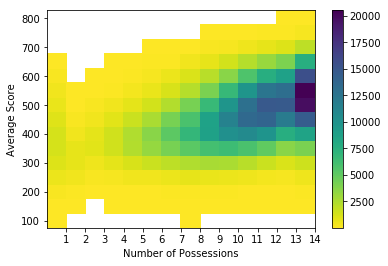

```python
# check the relationship between score and number of possessions by heatmap
plt.hist2d(data=score_poss, x='poss_num', y='score', cmin=10, cmap='viridis_r', bins=[bins_x, bins_y]);
plt.xticks((1,2,3,4,5,6,7,8,9,10,11,12, 13, 14))
plt.colorbar();
plt.xlabel('Number of Possessions');
plt.ylabel('Average Score');
```

#### A2.

As number of possessions growes, so does the average score

## Multivariate Exploration

In multivariate exploration, I will look at the relationship between multi variables and use scatter plot to visualize the results.

- KEYWORD : Gender, Scatter Plot

### Q1. How are gender, perceived control and perseverance related?

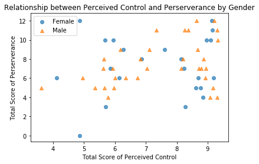

```python
# combine students with horizontal jitter
ttype_markers = [['Female', 'o'], ['Male', '^']]
for ttype, marker in ttype_markers:
    plot_data = multi1_subset.loc[multi1_subset['gender'] ==ttype]
    sb.regplot(data=plot_data, x='total_control', y='total_perserv', fit_reg=False, x_jitter=0.4, marker=marker,\
              scatter_kws={'alpha':0.7});

plt.xlabel('Total Score of Perceived Control')
plt.ylabel('Total Score of Perserverance');
plt.legend(['Female', 'Male']);
plt.title('Relationship between Perceived Control and Perserverance by Gender');
```

### Q2. How are gender, math work ethic and truancy related?

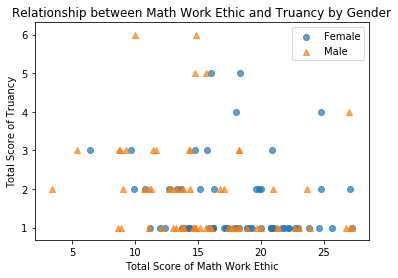

```python
# combine students with horizontal jitter
ttype_markers = [['Female', 'o'], ['Male', '^']]
for ttype, marker in ttype_markers:
    plot_data = multi2_subset.loc[multi2_subset['gender'] ==ttype]
    sb.regplot(data=plot_data, x='total_ethic', y='total_truancy', fit_reg=False, x_jitter=0.4, marker=marker,\
              scatter_kws={'alpha':0.7});

plt.xlabel('Total Score of Math Work Ethic')
plt.ylabel('Total Score of Truancy');
plt.legend(['Female', 'Male']);
plt.title('Relationship between Math Work Ethic and Truancy by Gender');
```

#### A2.

Most students have low Turancy score, especially who get higher than 10 in Math Work Ethic. The two highest Turancy score come from Male students.

### Conclusion

1. Many students regarded their relationship with teacher as great, but in case of sense of belonging, many students felt liked by others as well as lonely.
2. Number of possessions were related with high score.
3. Perserverance and Perceived Control seemed to be correlated a little, but there was no clear distinction between gender.